# Création de cartes choroplèthes avec {ggplot2}

## 0.1 Création de cartes choroplèthes avec {ggplot2}

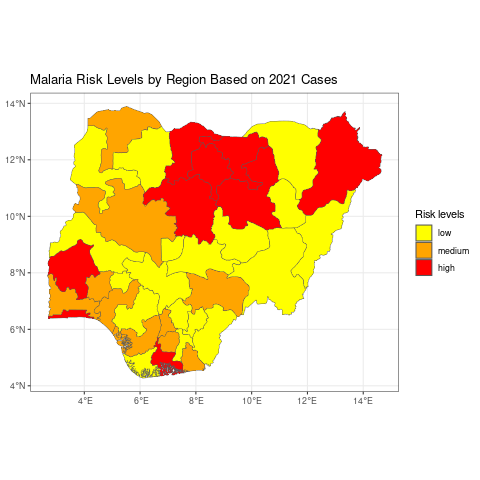

## 0.2 Objectifs d’apprentissage

‣ Reconnaître les composants d’une carte choroplèthe.

‣ Préparer des données spécifiquement pour la création d’une carte choroplèthe.

‣ Utiliser {ggplot2} dans R pour concevoir une carte choroplèthe.

‣ Mis en œuvre des techniques de mise à l’échelle des couleurs continues et discrètes.

‣ Intégré divers composants pour créer de petits multiples en utilisant `facet_wrap()` et `facet_grid()`.

## 0.3 Charger les packages nécessaires

```r
pacman::p_load(tidyverse, sf)
options(scipen=1000)  # Désactiver la notation scientifique pour des affichages numériques plus clairs
```

## 0.4 Préparation des données

1. Données géographiques (polygone) montrant les frontières du Nigeria.

```r
# Importation du shapefile du Nigeria
nga_adm1 <- st_read(here::here("data/raw/NGA_adm_shapefile/NGA_adm1.shp"))
```

‣ Affichage des régions administratives du Nigeria à l’aide d’un shapefile.

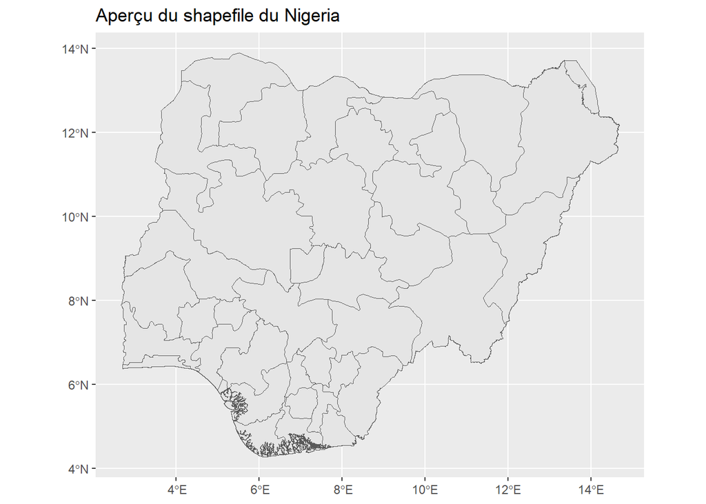

```r
# Commençons par visualiser notre shapefile
ggplot() +  # Nous initialisons une visualisation avec ggplot
  geom_sf(data = nga_adm1) +  # Nous ajoutons notre shapefile à la visualisation avec geom_sf()
  labs(title = "Aperçu du shapefile du Nigeria")  # Nous donnons un titre à notre graphique
```

2. Importation des données attributaires.

```r
malaria_cases <- read_csv(here::here("data/malaria.csv"))
```

3. Jointure et nettoyage des données

```r
# Est-ce qu'ils correspondent ?
setdiff(unique(nga_adm1$NAME_1), unique(malaria_cases$state_name))
```

```
## [1] "Water body"
```

```r
# Supprimer "Water body" de nos données
nga_adm1 <- filter(nga_adm1, NAME_1 != "Water body")
```

```r
# Jointure des ensembles de données
malaria2 <- malaria_cases %>%
  left_join(nga_adm1, by = c("state_name" = "NAME_1")) %>%
  st_as_sf()
```

```r
# Garder uniquement les colonnes essentielles
malaria2 <- malaria2 %>%
  select(state_name, cases_2000, cases_2006, cases_2010, cases_2015, cases_2021, geometry)
```

## 0.5 Réalisation d’une Carte Choroplèthe avec {ggplot2}

‣ Utilisation de l’argument `fill` dans `geom_sf()`.

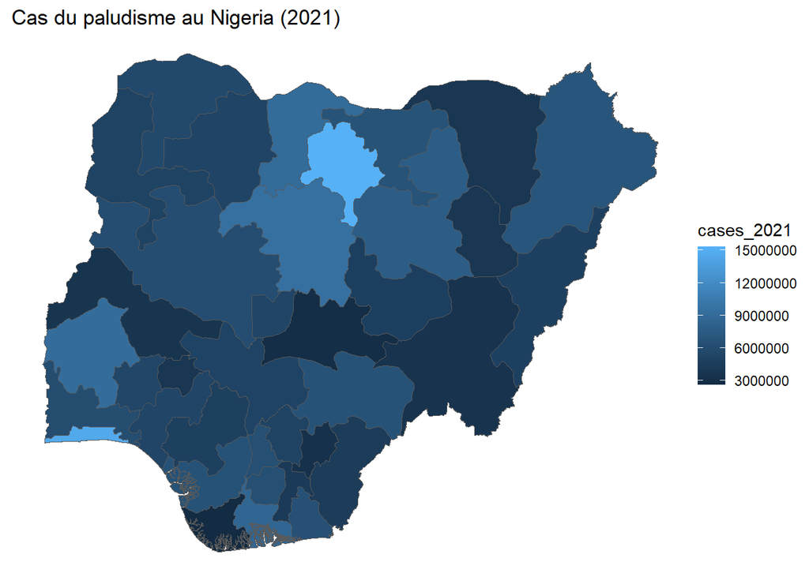

```r
# Commencez par une configuration de plot basique
ggplot(data = malaria2) +
  geom_sf(aes(fill = cases_2021)) +   # Remplissage basé sur les cas de 2021
  labs(title = "Cas du paludisme au Nigeria (2021)") +
  theme_void()
```

### 0.5.1 Personnalisation de la Carte

‣ Personnalisez la carte pour la rendre plus informative et attrayante en ajoutant divers éléments et styles.

‣ Titres, étiquettes d’axes, flèche du nord, barre d’échelle et thèmes…

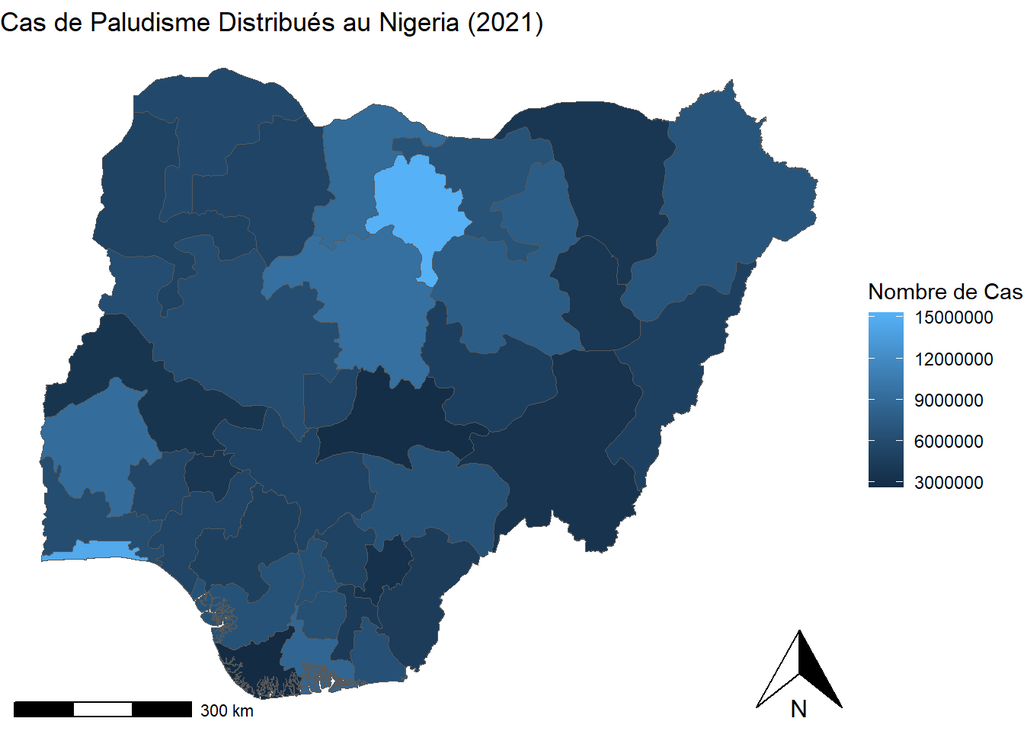

```r
# Ajoutez des améliorations à la carte
ggplot(data=malaria2) +
  geom_sf(aes(fill=cases_2021)) +
  labs(title = "Cas de Paludisme Distribués au Nigeria (2021)",
       fill = "Nombre de Cas",
       x = "Longitude",
       y = "Latitude") +
  theme_void() +
  ggspatial::annotation_north_arrow(location = "br")+
  ggspatial::annotation_scale(lcoation = "tr")
```